# Supervised Learning - ReCell Project

#### Test for Linearity and Independence

```python
# Creating a dataframe with actual, fitted and residual values
df_pred = pd.DataFrame()

df_pred["Actual Values"] = y_train  # actual
df_pred["Fitted Values"] = olsmod2.fittedvalues  # predicted values
df_pred["Residuals"] = olsmod2.resid  # residuals

df_pred.head()
```

|  | Actual Values | Fitted Values | Residuals |
| --- | --- | --- | --- |
| 3026 | 4.087488 | 3.858929 | 0.228559 |
| 1525 | 4.448399 | 4.614021 | -0.165621 |
| 1128 | 4.315353 | 4.277984 | 0.037368 |
| 3003 | 4.282068 | 4.251970 | 0.030098 |
| 2907 | 4.456438 | 4.439631 | 0.016807 |

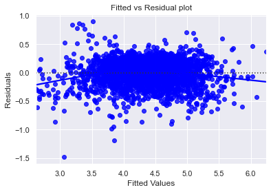

```python
# Plot fitted values vs residuals
sns.residplot(data=df_pred, x="Fitted Values", y="Residuals", color="blue", lowess=True)
plt.xlabel("Fitted Values")
plt.ylabel("Residuals")
plt.title("Fitted vs Residual plot")
plt.show()
```

The above scatter plot shows the distribution of residuals(errors) vs fitted values(predicted values)

There is no pattern in the above plot. The assumptions of linearity and independence are satisfied.

#### Test for Normality

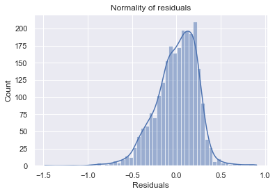

```python
sns.histplot(data=df_pred, x="Residuals", kde=True)
plt.title("Normality of residuals")
plt.show()
```

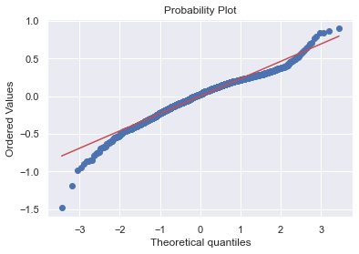

```python
import pylab
import scipy.stats as stats

stats.probplot(df_pred["Residuals"], dist="norm", plot=pylab)
plt.show()
```

The residuals generally follow a straight line except for the tails.

```python
stats.shapiro(df_pred["Residuals"])
```

```
ShapiroResult(statistic=0.9725338816642761, pvalue=3.889794212310738e-21)
```

Since p-value <0.05, the residuals are not normal as per the Shapiro-Wilk test

We can conclude that the residuals are not normal.

However, as an approximation, we can accept this distribution as close to being normal and conclude that the assumption is satisfied.

#### Test for Homoscedasticity

```python
import statsmodels.stats.api as sms
from statsmodels.compat import lzip

name = ["F statistic", "p_value"]
test = sms.het_goldfeldquandt(df_pred["Residuals"], x_train3)
lzip(name, test)
```

```
[('F statistic', 1.0557528213860063), ('p_value', 0.1740978166862373)]
```

Since p-value >0.05, we can conclude that the residuals are homoscedastic and that the assumption is satisfied.

#### Predictions on Test Data

```python
# predictions on the test set
pred = olsmod2.predict(x_test3)

df_pred_test = pd.DataFrame({"Actual": y_test, "Predicted": pred})
df_pred_test.sample(10, random_state=1)
```

|  | Actual | Predicted |
| --- | --- | --- |
| 1995 | 4.566741 | 4.370351 |
| 2341 | 3.696103 | 3.954841 |
| 1913 | 3.592093 | 3.760864 |
| 688 | 4.306495 | 4.099103 |
| 650 | 4.522115 | 5.117765 |
| 2291 | 4.259294 | 4.392319 |
| 40 | 4.997685 | 5.404183 |
| 1884 | 3.875359 | 4.103916 |
| 2538 | 4.206631 | 4.044660 |
| 45 | 5.380450 | 5.301280 |

Generally, our model shows good prediction results, and the actual and predicted values are comparable.

## Final Model

```python
x_train_final = x_train3.copy()
x_test_final = x_test3.copy()
```

```python
olsmodel_final = sm.OLS(y_train, x_train_final).fit()
print(olsmodel_final.summary())
```

```
                              OLS Regression Results
=================================================================================
Dep. Variable:     normalized_used_price   R-squared:                       0.839
Model:                               OLS   Adj. R-squared:                  0.839
Method:                    Least Squares   F-statistic:                     1143.
Date:                   Thu, 07 Jul 2022   Prob (F-statistic):               0.00
Time:                           11:51:15   Log-Likelihood:                 82.276
No. Observations:                   2417   AIC:                            -140.6
Df Residuals:                       2405   BIC:                            -71.07
Df Model:                             11
Covariance Type:               nonrobust
========================================================================================
                           coef    std err          t      P>|t|      [0.025      0.975]
----------------------------------------------------------------------------------------
const                    1.2074      0.046     26.209      0.000       1.117       1.298
screen_size              0.0432      0.002     28.318      0.000       0.040       0.046
main_camera_mp           0.0190      0.001     14.019      0.000       0.016       0.022
selfie_camera_mp         0.0131      0.001     12.353      0.000       0.011       0.015
ram                      0.0177      0.004      4.022      0.000       0.009       0.026
days_used             6.297e-05   3.03e-05      2.077      0.038    3.51e-06       0.000
normalized_new_price     0.4283      0.011     39.663      0.000       0.407       0.449
years_since_release     -0.0179      0.004     -4.144      0.000      -0.026      -0.009
brand_name_Lenovo        0.0492      0.022      2.277      0.023       0.007       0.092
brand_name_Nokia         0.0734      0.030      2.468      0.014       0.015       0.132
brand_name_Xiaomi        0.0855      0.026      3.336      0.001       0.035       0.136
4g_yes                   0.0366      0.015      2.438      0.015       0.007       0.066
==============================================================================
Omnibus:                      215.934   Durbin-Watson:                   1.915
Prob(Omnibus):                  0.000   Jarque-Bera (JB):              402.040
Skew:                          -0.607   Prob(JB):                     4.99e-88
Kurtosis:                       4.588   Cond. No.                     7.12e+03
==============================================================================

Notes:
[1] Standard Errors assume that the covariance matrix of the errors is correctly specified.
[2] The condition number is large, 7.12e+03. This might indicate that there are
strong multicollinearity or other numerical problems.
```

```python
# Check model performance on train set (70% data)
print("Training Performance\n")
olsmodel_final_train_perf = model_performance_regression(
    olsmodel_final, x_train_final, y_train
)
olsmodel_final_train_perf
```

```
Training Performance
```

|  | RMSE | MAE | R-squared | Adj. R-squared | MAPE |
| --- | --- | --- | --- | --- | --- |
| 0 | 0.233873 | 0.183042 | 0.839457 | 0.838655 | 4.388629 |

```python
# Check model performance on test set (30% data)
print("Test Performance\n")
olsmodel_final_test_perf = model_performance_regression(
    olsmodel_final, x_test_final, y_test
)
olsmodel_final_test_perf
```

```
Test Performance
```

|  | RMSE | MAE | R-squared | Adj. R-squared | MAPE |
| --- | --- | --- | --- | --- | --- |
| 0 | 0.238582 | 0.185026 | 0.842182 | 0.840333 | 4.501915 |

The model is able to explain 84% of the variation in the data.

Both the train and test RMSE and MAE are low and comparable. This indicates that the model is not suffering from overfitting.

The MAPE on the test set indicates that we can predict within 4.5% of the price of a used phone/tablet.

We can conclude the model olsmodel_final is good for prediction and for inference purposes.

## Actionable Insights and Recommendations

The model is able to explain 84% of the variation in the data and within 4.5% of the used phone price on the test data. This indicates that the model is good for prediction and also for inference purposes.

The number of days used does not greatly affect the price of the phone as long as the phone has the features that the customer wants.

Phones with the Android operating system are by far the most popular. ReCell should continue to purchase phones with Android OS in order to help increase sales.

Only 4.4% of all used phones have 5g capability. As consumers continue to prefer devices with 5g technology, ReCell will have to shift to buying more phones that have 5g technology.

The price of a used phone is highly correlated to the price of a new phone. As new phones introduce promotions that will reduce the price of a new phone, ReCell will also need to adapt to these discounts and adjust their prices in order to remain competitive.

Customers have increased their demand for phones that are faster, have better battery life, and can take better pictures. Therefore, ReCell should focus on buying phones that have greater than 4GB of RAM, Battery capacity greater than 4500mAh, screen size greater than 6 inches, main cameras greater than 8 MP and selfie cameras greater than 5 MP.